# SR_03_RLTD_ORG_PTR_ADDR_CITY

Related organization city · Text report

## Overview

**Description**

Address Foreign - City

**Table**

`SR-P03-T01-ID-RLTD-ORGS-TAXABLE-PARTNERSHIP` (many)

**Location code**

`SCHED-R-PART-03-COL-A`

**Family**

`SCHED-R-PART-03-COL-A` · siblings: SR_03_RLTD_ORG_PTR_ADDR_CNTR, SR_03_RLTD_ORG_PTR_ADDR_L1, SR_03_RLTD_ORG_PTR_ADDR_L2, SR_03_RLTD_ORG_PTR_ADDR_STATE, SR_03_RLTD_ORG_PTR_ADDR_ZIP, SR_03_RLTD_ORG_PTR_EIN

**Data type**

text (xsd: TextType, CityType)

**Scope**

PC

**Status**

unreviewed

6

xpaths mapped (6 observed)

146,982

filings with a value

2009–2024

tax years observed

1

open flags (1 errors)

## Flags

| Severity | Flag | Xpath | Detail |
| --- | --- | --- | --- |
| ⚠ error | `COLLISION` | IRS990ScheduleR/IdRelatedOrgTxblPartnershipGrp/ForeignAddress/CityNm | 2274 filings contain 2+ of its xpaths; most common set: /Return/ReturnData/IRS990ScheduleR/IdRelatedOrgTxblPartnershipGrp/ForeignAddress/CityNm ; /Return/ReturnData/IRS990ScheduleR/IdRelatedOrgTxblPar… |

## Xpaths

All mapped xpaths (under /Return/ReturnData or /Return/ReturnHeader), oldest first. Charts label each series by its xpath.

| Xpath | Form | Chart label | First year | Last year | Versions | Filings | Repeats in |
| --- | --- | --- | --- | --- | --- | --- | --- |
| IRS990ScheduleR/Form990ScheduleRPartIII/AddressUS/City | Sched R | same | 2009 | 2012 | 16 | 23,460 | 65.1% |
| IRS990ScheduleR/Form990ScheduleRPartIII/AddressForeign/City | Sched R | same | 2009 | 2012 | 12 | 166 | 71.7% |
| IRS990ScheduleR/IdRelatedOrgTxblPartnershipGrp/USAddress/City | Sched R | …90ScheduleR/IdRelatedOrgTxblPartnershipGrp/USAddress/City | 2013 | 2013 | 3 | 8,258 | 65.2% |
| IRS990ScheduleR/IdRelatedOrgTxblPartnershipGrp/ForeignAddress/City | Sched R | …eduleR/IdRelatedOrgTxblPartnershipGrp/ForeignAddress/City | 2013 | 2013 | 3 | 61 | 52.5% |
| IRS990ScheduleR/IdRelatedOrgTxblPartnershipGrp/USAddress/CityNm | Sched R | …ScheduleR/IdRelatedOrgTxblPartnershipGrp/USAddress/CityNm | 2014 | 2024 | 34 | 112,705 | 66.8% |
| IRS990ScheduleR/IdRelatedOrgTxblPartnershipGrp/ForeignAddress/CityNm | Sched R | …uleR/IdRelatedOrgTxblPartnershipGrp/ForeignAddress/CityNm | 2014 | 2024 | 31 | 2,332 | 48.3% |

## Coverage

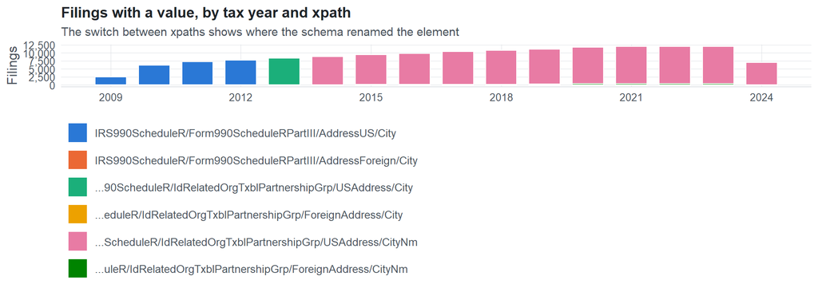

**Table view**

Table view: filings by tax year and series

| Tax year | IRS990ScheduleR/Form990ScheduleRPartIII/AddressUS/City | IRS990ScheduleR/Form990ScheduleRPartIII/AddressForeign/City | …90ScheduleR/IdRelatedOrgTxblPartnershipGrp/USAddress/City | …eduleR/IdRelatedOrgTxblPartnershipGrp/ForeignAddress/City | …ScheduleR/IdRelatedOrgTxblPartnershipGrp/USAddress/CityNm | …uleR/IdRelatedOrgTxblPartnershipGrp/ForeignAddress/CityNm |
| --- | --- | --- | --- | --- | --- | --- |
| 2009 | 2,408 | 22 | 0 | 0 | 0 | 0 |
| 2010 | 6,092 | 50 | 0 | 0 | 0 | 0 |
| 2011 | 7,239 | 45 | 0 | 0 | 0 | 0 |
| 2012 | 7,721 | 49 | 0 | 0 | 0 | 0 |
| 2013 | 0 | 0 | 8,258 | 61 | 0 | 0 |
| 2014 | 0 | 0 | 0 | 0 | 8,789 | 61 |
| 2015 | 0 | 0 | 0 | 0 | 9,294 | 112 |
| 2016 | 0 | 0 | 0 | 0 | 9,719 | 121 |
| 2017 | 0 | 0 | 0 | 0 | 10,305 | 108 |
| 2018 | 0 | 0 | 0 | 0 | 10,609 | 128 |
| 2019 | 0 | 0 | 0 | 0 | 10,877 | 282 |
| 2020 | 0 | 0 | 0 | 0 | 11,397 | 341 |
| 2021 | 0 | 0 | 0 | 0 | 11,570 | 355 |
| 2022 | 0 | 0 | 0 | 0 | 11,667 | 356 |
| 2023 | 0 | 0 | 0 | 0 | 11,569 | 376 |
| 2024 | 0 | 0 | 0 | 0 | 6,909 | 92 |

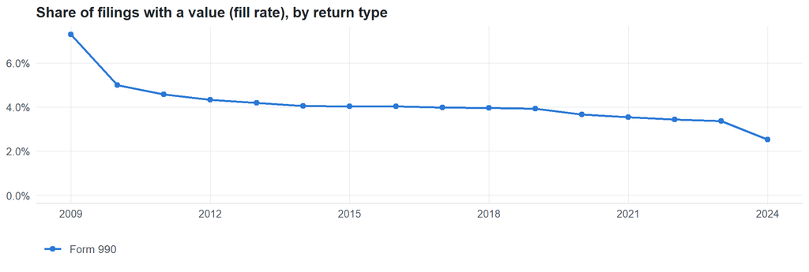

**Table view**

Table view: fill rate

| Tax year | Return type | Filings | All filings | Fill rate |
| --- | --- | --- | --- | --- |
| 2009 | Form 990 | 2,430 | 33,311 | 7.29% |
| 2010 | Form 990 | 6,142 | 123,025 | 4.99% |
| 2011 | Form 990 | 7,284 | 159,504 | 4.57% |
| 2012 | Form 990 | 7,770 | 179,688 | 4.32% |
| 2013 | Form 990 | 8,319 | 198,855 | 4.18% |
| 2014 | Form 990 | 8,850 | 218,619 | 4.05% |
| 2015 | Form 990 | 9,406 | 233,519 | 4.03% |
| 2016 | Form 990 | 9,840 | 243,903 | 4.03% |
| 2017 | Form 990 | 10,413 | 261,612 | 3.98% |
| 2018 | Form 990 | 10,737 | 271,442 | 3.96% |
| 2019 | Form 990 | 11,159 | 283,694 | 3.93% |
| 2020 | Form 990 | 11,738 | 320,342 | 3.66% |
| 2021 | Form 990 | 11,925 | 336,480 | 3.54% |
| 2022 | Form 990 | 12,023 | 349,055 | 3.44% |
| 2023 | Form 990 | 11,945 | 354,768 | 3.37% |
| 2024 | Form 990 | 7,001 | 277,298 | 2.52% |

## Repeating groups

Table cardinality in the concordance: **many**. 6 of 6 observed xpaths repeat within a filing.

Repeating element each xpath was observed in (from the raw indexed xpath)

| Xpath | Repeating element | Filings (summed over years) |
| --- | --- | --- |
| IRS990ScheduleR/Form990ScheduleRPartIII/AddressForeign/City | (none) | 29 |
| IRS990ScheduleR/Form990ScheduleRPartIII/AddressForeign/City | IRS990ScheduleR/Form990ScheduleRPartIII | 137 |
| IRS990ScheduleR/Form990ScheduleRPartIII/AddressUS/City | (none) | 8148 |
| IRS990ScheduleR/Form990ScheduleRPartIII/AddressUS/City | IRS990ScheduleR/Form990ScheduleRPartIII | 15312 |
| IRS990ScheduleR/IdRelatedOrgTxblPartnershipGrp/ForeignAddress/City | (none) | 18 |
| IRS990ScheduleR/IdRelatedOrgTxblPartnershipGrp/ForeignAddress/City | IRS990ScheduleR/IdRelatedOrgTxblPartnershipGrp | 43 |
| IRS990ScheduleR/IdRelatedOrgTxblPartnershipGrp/USAddress/City | (none) | 2857 |
| IRS990ScheduleR/IdRelatedOrgTxblPartnershipGrp/USAddress/City | IRS990ScheduleR/IdRelatedOrgTxblPartnershipGrp | 5401 |
| IRS990ScheduleR/IdRelatedOrgTxblPartnershipGrp/ForeignAddress/CityNm | (none) | 207 |
| IRS990ScheduleR/IdRelatedOrgTxblPartnershipGrp/ForeignAddress/CityNm | IRS990ScheduleR/IdRelatedOrgTxblPartnershipGrp | 2125 |
| IRS990ScheduleR/IdRelatedOrgTxblPartnershipGrp/USAddress/CityNm | (none) | 37222 |
| IRS990ScheduleR/IdRelatedOrgTxblPartnershipGrp/USAddress/CityNm | IRS990ScheduleR/IdRelatedOrgTxblPartnershipGrp | 75483 |

## Values

| Result | Check | Detail |
| --- | --- | --- |
| ✓ pass | Values are text, not numbers | 0% of values are numeric |
| ⓘ info | No sign of truncation | IRS990ScheduleR/Form990ScheduleRPartIII/AddressForeign/City: longest value is exactly 35 characters; …eduleR/IdRelatedOrgTxblPartnershipGrp/ForeignAddress/City: longest value is exactly 35 characters;… |
| ⓘ info | No dominant boilerplate value | most common value covers 37% of filings: “HONG KONG” |

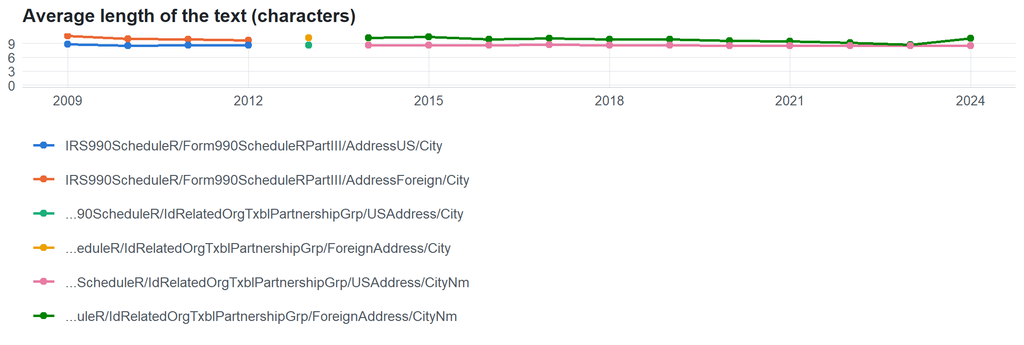

**Table view**

Table view: length and variety by tax year

| Series | Tax year | Filings | Avg length | Max length | Distinct values (approx.) |
| --- | --- | --- | --- | --- | --- |
| IRS990ScheduleR/Form990ScheduleRPartIII/AddressUS/City | 2009 | 2,408 | 9 | 22 | 978 |
| IRS990ScheduleR/Form990ScheduleRPartIII/AddressUS/City | 2010 | 6,092 | 9 | 22 | 1,292 |
| IRS990ScheduleR/Form990ScheduleRPartIII/AddressUS/City | 2011 | 7,239 | 9 | 22 | 1,532 |
| IRS990ScheduleR/Form990ScheduleRPartIII/AddressUS/City | 2012 | 7,721 | 9 | 22 | 1,921 |
| IRS990ScheduleR/Form990ScheduleRPartIII/AddressForeign/City | 2009 | 22 | 11 | 22 | 20 |
| IRS990ScheduleR/Form990ScheduleRPartIII/AddressForeign/City | 2010 | 50 | 10 | 32 | 35 |
| IRS990ScheduleR/Form990ScheduleRPartIII/AddressForeign/City | 2011 | 45 | 10 | 35 | 38 |
| IRS990ScheduleR/Form990ScheduleRPartIII/AddressForeign/City | 2012 | 49 | 10 | 35 | 18 |
| …90ScheduleR/IdRelatedOrgTxblPartnershipGrp/USAddress/City | 2013 | 8,258 | 9 | 22 | 1,341 |
| …eduleR/IdRelatedOrgTxblPartnershipGrp/ForeignAddress/City | 2013 | 61 | 10 | 35 | 33 |
| …ScheduleR/IdRelatedOrgTxblPartnershipGrp/USAddress/CityNm | 2014 | 8,789 | 9 | 22 | 2,111 |
| …ScheduleR/IdRelatedOrgTxblPartnershipGrp/USAddress/CityNm | 2015 | 9,294 | 9 | 22 | 2,253 |
| …ScheduleR/IdRelatedOrgTxblPartnershipGrp/USAddress/CityNm | 2016 | 9,719 | 9 | 22 | 2,644 |
| …ScheduleR/IdRelatedOrgTxblPartnershipGrp/USAddress/CityNm | 2017 | 10,305 | 9 | 22 | 2,150 |
| …ScheduleR/IdRelatedOrgTxblPartnershipGrp/USAddress/CityNm | 2018 | 10,609 | 9 | 22 | 1,936 |
| …ScheduleR/IdRelatedOrgTxblPartnershipGrp/USAddress/CityNm | 2019 | 10,877 | 9 | 22 | 1,660 |
| …ScheduleR/IdRelatedOrgTxblPartnershipGrp/USAddress/CityNm | 2020 | 11,397 | 9 | 22 | 1,678 |
| …ScheduleR/IdRelatedOrgTxblPartnershipGrp/USAddress/CityNm | 2021 | 11,570 | 9 | 22 | 2,325 |
| …ScheduleR/IdRelatedOrgTxblPartnershipGrp/USAddress/CityNm | 2022 | 11,667 | 9 | 22 | 2,829 |
| …ScheduleR/IdRelatedOrgTxblPartnershipGrp/USAddress/CityNm | 2023 | 11,569 | 9 | 22 | 1,851 |
| …ScheduleR/IdRelatedOrgTxblPartnershipGrp/USAddress/CityNm | 2024 | 6,909 | 8 | 22 | 1,456 |
| …uleR/IdRelatedOrgTxblPartnershipGrp/ForeignAddress/CityNm | 2014 | 61 | 10 | 35 | 32 |
| …uleR/IdRelatedOrgTxblPartnershipGrp/ForeignAddress/CityNm | 2015 | 112 | 10 | 35 | 39 |
| …uleR/IdRelatedOrgTxblPartnershipGrp/ForeignAddress/CityNm | 2016 | 121 | 10 | 31 | 36 |
| …uleR/IdRelatedOrgTxblPartnershipGrp/ForeignAddress/CityNm | 2017 | 108 | 10 | 31 | 28 |
| …uleR/IdRelatedOrgTxblPartnershipGrp/ForeignAddress/CityNm | 2018 | 128 | 10 | 19 | 33 |
| …uleR/IdRelatedOrgTxblPartnershipGrp/ForeignAddress/CityNm | 2019 | 282 | 10 | 29 | 27 |
| …uleR/IdRelatedOrgTxblPartnershipGrp/ForeignAddress/CityNm | 2020 | 341 | 10 | 29 | 34 |
| …uleR/IdRelatedOrgTxblPartnershipGrp/ForeignAddress/CityNm | 2021 | 355 | 9 | 28 | 53 |
| …uleR/IdRelatedOrgTxblPartnershipGrp/ForeignAddress/CityNm | 2022 | 356 | 9 | 28 | 56 |
| …uleR/IdRelatedOrgTxblPartnershipGrp/ForeignAddress/CityNm | 2023 | 376 | 9 | 26 | 60 |
| …uleR/IdRelatedOrgTxblPartnershipGrp/ForeignAddress/CityNm | 2024 | 92 | 10 | 25 | 65 |

Most common values by xpath (all years; long values truncated)

| Series | Value | Filings | Share |
| --- | --- | --- | --- |
| IRS990ScheduleR/Form990ScheduleRPartIII/AddressUS/City | CHICAGO | 1,030 | 4.4% |
| IRS990ScheduleR/Form990ScheduleRPartIII/AddressUS/City | TOLEDO | 967 | 4.1% |
| IRS990ScheduleR/Form990ScheduleRPartIII/AddressUS/City | COLUMBUS | 946 | 4.0% |
| IRS990ScheduleR/Form990ScheduleRPartIII/AddressUS/City | CLEVELAND | 928 | 4.0% |
| IRS990ScheduleR/Form990ScheduleRPartIII/AddressUS/City | ST LOUIS | 802 | 3.4% |
| IRS990ScheduleR/Form990ScheduleRPartIII/AddressUS/City | YPSILANTI | 771 | 3.3% |
| IRS990ScheduleR/Form990ScheduleRPartIII/AddressUS/City | BOSTON | 736 | 3.1% |
| IRS990ScheduleR/Form990ScheduleRPartIII/AddressUS/City | WARREN | 700 | 3.0% |
| IRS990ScheduleR/Form990ScheduleRPartIII/AddressUS/City | SACRAMENTO | 596 | 2.5% |
| IRS990ScheduleR/Form990ScheduleRPartIII/AddressUS/City | NEW YORK | 550 | 2.3% |
| IRS990ScheduleR/Form990ScheduleRPartIII/AddressUS/City | ATLANTA | 210 | 0.9% |
| IRS990ScheduleR/Form990ScheduleRPartIII/AddressUS/City | SAN MARCOS | 208 | 0.9% |
| IRS990ScheduleR/Form990ScheduleRPartIII/AddressUS/City | Baltimore | 124 | 0.5% |
| IRS990ScheduleR/Form990ScheduleRPartIII/AddressUS/City | Denver | 115 | 0.5% |
| IRS990ScheduleR/Form990ScheduleRPartIII/AddressUS/City | Lexington | 103 | 0.4% |
| IRS990ScheduleR/Form990ScheduleRPartIII/AddressUS/City | Englewood | 102 | 0.4% |
| IRS990ScheduleR/Form990ScheduleRPartIII/AddressUS/City | Lakewood | 101 | 0.4% |
| IRS990ScheduleR/Form990ScheduleRPartIII/AddressUS/City | Lincoln | 101 | 0.4% |
| IRS990ScheduleR/Form990ScheduleRPartIII/AddressUS/City | Tacoma | 101 | 0.4% |
| IRS990ScheduleR/Form990ScheduleRPartIII/AddressUS/City | Breckenridge | 100 | 0.4% |
| IRS990ScheduleR/Form990ScheduleRPartIII/AddressUS/City | Clive | 100 | 0.4% |
| IRS990ScheduleR/Form990ScheduleRPartIII/AddressUS/City | Colorado Springs | 100 | 0.4% |
| IRS990ScheduleR/Form990ScheduleRPartIII/AddressForeign/City | ST. HELIER | 55 | 33.1% |
| IRS990ScheduleR/Form990ScheduleRPartIII/AddressForeign/City | SAO PAULO | 46 | 27.7% |
| IRS990ScheduleR/Form990ScheduleRPartIII/AddressForeign/City | GEORGE TOWN | 45 | 27.1% |
| IRS990ScheduleR/Form990ScheduleRPartIII/AddressForeign/City | AMSTERDAM | 43 | 25.9% |
| IRS990ScheduleR/Form990ScheduleRPartIII/AddressForeign/City | SYDNEY | 43 | 25.9% |
| IRS990ScheduleR/Form990ScheduleRPartIII/AddressForeign/City | VITACURA | 43 | 25.9% |
| IRS990ScheduleR/Form990ScheduleRPartIII/AddressForeign/City | TORONTO | 30 | 18.1% |
| IRS990ScheduleR/Form990ScheduleRPartIII/AddressForeign/City | LONDON | 16 | 9.6% |

First rows shown.

## Examples

| Tax year | Return | Xpath | Organization | Value | Source |
| --- | --- | --- | --- | --- | --- |
| 2024 | 990 | IRS990ScheduleR/IdRelatedOrgTxblPartnershipGrp/ForeignAddress/CityNm | THE CLEVELAND CLINIC FOUNDATION | GEORGE TOWN | [XML](https://gt990datalake-rawdata.s3.amazonaws.com/EfileData/XmlFiles/202513189349302136_public.xml) |
| 2024 | 990 | IRS990ScheduleR/IdRelatedOrgTxblPartnershipGrp/USAddress/CityNm | RISEWELL COMMUNITY SERVICES INC FKA | WEST BABYLON | [XML](https://gt990datalake-rawdata.s3.amazonaws.com/EfileData/XmlFiles/202610589349301811_public.xml) |
| 2023 | 990 | IRS990ScheduleR/IdRelatedOrgTxblPartnershipGrp/ForeignAddress/CityNm | THE FULLER FOUNDATION | GEORGE TOWN | [XML](https://gt990datalake-rawdata.s3.amazonaws.com/EfileData/XmlFiles/202403169349306145_public.xml) |
| 2023 | 990 | IRS990ScheduleR/IdRelatedOrgTxblPartnershipGrp/USAddress/CityNm | Beattie House Inc | Littleton | [XML](https://gt990datalake-rawdata.s3.amazonaws.com/EfileData/XmlFiles/202401109349300515_public.xml) |
| 2022 | 990 | IRS990ScheduleR/IdRelatedOrgTxblPartnershipGrp/ForeignAddress/CityNm | DUKE MEDICINE GLOBAL SUPPORT CORPORATION | EDINBURGH | [XML](https://gt990datalake-rawdata.s3.amazonaws.com/EfileData/XmlFiles/202431359349305623_public.xml) |
| 2022 | 990 | IRS990ScheduleR/IdRelatedOrgTxblPartnershipGrp/USAddress/CityNm | Providence Brown Street Housing | Rochester | [XML](https://gt990datalake-rawdata.s3.amazonaws.com/EfileData/XmlFiles/202411239349300546_public.xml) |
| 2021 | 990 | IRS990ScheduleR/IdRelatedOrgTxblPartnershipGrp/ForeignAddress/CityNm | CHI ST JOSEPH’S CHILDREN | HONG KONG | [XML](https://gt990datalake-rawdata.s3.amazonaws.com/EfileData/XmlFiles/202321299349302707_public.xml) |
| 2021 | 990 | IRS990ScheduleR/IdRelatedOrgTxblPartnershipGrp/USAddress/CityNm | St John Providence | ST LOUIS | [XML](https://gt990datalake-rawdata.s3.amazonaws.com/EfileData/XmlFiles/202311329349304191_public.xml) |
| 2020 | 990 | IRS990ScheduleR/IdRelatedOrgTxblPartnershipGrp/ForeignAddress/CityNm | ST LUKE’S PROPERTIES CORPORATION | HONG KONG | [XML](https://gt990datalake-rawdata.s3.amazonaws.com/EfileData/XmlFiles/202241369349302974_public.xml) |
| 2020 | 990 | IRS990ScheduleR/IdRelatedOrgTxblPartnershipGrp/USAddress/CityNm | VOLUNTEERS OF AMERICA INC | ALEXANDRIA | [XML](https://gt990datalake-rawdata.s3.amazonaws.com/EfileData/XmlFiles/202133159349302793_public.xml) |
| 2019 | 990 | IRS990ScheduleR/IdRelatedOrgTxblPartnershipGrp/ForeignAddress/CityNm | DUKE AFFILIATIONS NETWORK INC | GRAND CAYMAN | [XML](https://gt990datalake-rawdata.s3.amazonaws.com/EfileData/XmlFiles/202111369349301521_public.xml) |
| 2019 | 990 | IRS990ScheduleR/IdRelatedOrgTxblPartnershipGrp/USAddress/CityNm | SOUTHFIELD NON-PROFIT HOUSING CORP | SOUTHFIELD | [XML](https://gt990datalake-rawdata.s3.amazonaws.com/EfileData/XmlFiles/202013169349303486_public.xml) |

## Reviewer checklist

- The definition matches the form line and instructions for every xpath’s schema years.
- Every xpath pooled here measures the same thing on the 990 and 990-EZ (close enough for analysis).
- The coverage chart has no unexplained gaps or jumps between tax years.
- Each open flag is fixed, or accepted with a note in validation_log.csv.
- Values answer the question on the form line (not another line’s explanation).
- Boilerplate such as ‘See Schedule O’ or ‘N/A’ is expected here, or should be treated as missing.
- Text that is really a number or a code is flagged for a different data type.

Record the review as a row in `inst/extdata/src/validation_log.csv` (variable_name, reviewer, date, status, note). Evidence built 2026-09-23 17:09:04 MST from the ef2 DuckDB builds (tax years 2009–2024).